# Risk Factor Analysis

## Outcome Variable

**Outcome Variable:** y_rate_wtkg

## Predictor Variables

**Intervention Variable:** predfeed3

**Adjustment Set:**

unadjusted

## Stratifying Variables

The analysis was stratified on these variable(s):

- agecat
- studyid
- country

## Data Summary

| agecat | studyid | country | predfeed3 | n_cell | n |
| --- | --- | --- | --- | --- | --- |
| 0-3 months | EE | PAKISTAN | 1 | 32 | 32 |
| 0-3 months | EE | PAKISTAN | 0 | 0 | 32 |
| 0-3 months | GMS-Nepal | NEPAL | 1 | 378 | 455 |
| 0-3 months | GMS-Nepal | NEPAL | 0 | 77 | 455 |
| 0-3 months | JiVitA-3 | BANGLADESH | 1 | 10915 | 12097 |
| 0-3 months | JiVitA-3 | BANGLADESH | 0 | 1182 | 12097 |
| 0-3 months | JiVitA-4 | BANGLADESH | 1 | 108 | 119 |
| 0-3 months | JiVitA-4 | BANGLADESH | 0 | 11 | 119 |
| 0-3 months | MAL-ED | BANGLADESH | 1 | 195 | 239 |
| 0-3 months | MAL-ED | BANGLADESH | 0 | 44 | 239 |
| 0-3 months | MAL-ED | BRAZIL | 1 | 96 | 195 |
| 0-3 months | MAL-ED | BRAZIL | 0 | 99 | 195 |
| 0-3 months | MAL-ED | INDIA | 1 | 151 | 213 |
| 0-3 months | MAL-ED | INDIA | 0 | 62 | 213 |
| 0-3 months | MAL-ED | NEPAL | 1 | 111 | 224 |
| 0-3 months | MAL-ED | NEPAL | 0 | 113 | 224 |
| 0-3 months | MAL-ED | PERU | 1 | 181 | 279 |
| 0-3 months | MAL-ED | PERU | 0 | 98 | 279 |
| 0-3 months | MAL-ED | SOUTH AFRICA | 1 | 70 | 261 |
| 0-3 months | MAL-ED | SOUTH AFRICA | 0 | 191 | 261 |
| 0-3 months | MAL-ED | TANZANIA, UNITED REPUBLIC OF | 1 | 59 | 205 |
| 0-3 months | MAL-ED | TANZANIA, UNITED REPUBLIC OF | 0 | 146 | 205 |
| 3-6 months | EE | PAKISTAN | 1 | 30 | 30 |
| 3-6 months | EE | PAKISTAN | 0 | 0 | 30 |
| 3-6 months | GMS-Nepal | NEPAL | 1 | 351 | 420 |
| 3-6 months | GMS-Nepal | NEPAL | 0 | 69 | 420 |
| 3-6 months | JiVitA-3 | BANGLADESH | 1 | 6540 | 7170 |
| 3-6 months | JiVitA-3 | BANGLADESH | 0 | 630 | 7170 |
| 3-6 months | JiVitA-4 | BANGLADESH | 1 | 20 | 21 |
| 3-6 months | JiVitA-4 | BANGLADESH | 0 | 1 | 21 |

[output cut: 130 more lines]

The following strata were considered:

- agecat: 0-3 months, studyid: EE, country: PAKISTAN
- agecat: 0-3 months, studyid: GMS-Nepal, country: NEPAL
- agecat: 0-3 months, studyid: JiVitA-3, country: BANGLADESH
- agecat: 0-3 months, studyid: JiVitA-4, country: BANGLADESH
- agecat: 0-3 months, studyid: MAL-ED, country: BANGLADESH
- agecat: 0-3 months, studyid: MAL-ED, country: BRAZIL
- agecat: 0-3 months, studyid: MAL-ED, country: INDIA
- agecat: 0-3 months, studyid: MAL-ED, country: NEPAL
- agecat: 0-3 months, studyid: MAL-ED, country: PERU
- agecat: 0-3 months, studyid: MAL-ED, country: SOUTH AFRICA
- agecat: 0-3 months, studyid: MAL-ED, country: TANZANIA, UNITED REPUBLIC OF
- agecat: 12-15 months, studyid: EE, country: PAKISTAN
- agecat: 12-15 months, studyid: GMS-Nepal, country: NEPAL
- agecat: 12-15 months, studyid: JiVitA-4, country: BANGLADESH
- agecat: 12-15 months, studyid: MAL-ED, country: BANGLADESH
- agecat: 12-15 months, studyid: MAL-ED, country: BRAZIL
- agecat: 12-15 months, studyid: MAL-ED, country: INDIA
- agecat: 12-15 months, studyid: MAL-ED, country: NEPAL
- agecat: 12-15 months, studyid: MAL-ED, country: PERU
- agecat: 12-15 months, studyid: MAL-ED, country: SOUTH AFRICA
- agecat: 12-15 months, studyid: MAL-ED, country: TANZANIA, UNITED REPUBLIC OF
- agecat: 15-18 months, studyid: EE, country: PAKISTAN
- agecat: 15-18 months, studyid: GMS-Nepal, country: NEPAL
- agecat: 15-18 months, studyid: JiVitA-4, country: BANGLADESH
- agecat: 15-18 months, studyid: MAL-ED, country: BANGLADESH
- agecat: 15-18 months, studyid: MAL-ED, country: BRAZIL
- agecat: 15-18 months, studyid: MAL-ED, country: INDIA
- agecat: 15-18 months, studyid: MAL-ED, country: NEPAL
- agecat: 15-18 months, studyid: MAL-ED, country: PERU
- agecat: 15-18 months, studyid: MAL-ED, country: SOUTH AFRICA
- agecat: 15-18 months, studyid: MAL-ED, country: TANZANIA, UNITED REPUBLIC OF
- agecat: 18-21 months, studyid: EE, country: PAKISTAN
- agecat: 18-21 months, studyid: GMS-Nepal, country: NEPAL
- agecat: 18-21 months, studyid: MAL-ED, country: BANGLADESH
- agecat: 18-21 months, studyid: MAL-ED, country: BRAZIL
- agecat: 18-21 months, studyid: MAL-ED, country: INDIA
- agecat: 18-21 months, studyid: MAL-ED, country: NEPAL
- agecat: 18-21 months, studyid: MAL-ED, country: PERU
- agecat: 18-21 months, studyid: MAL-ED, country: SOUTH AFRICA
- agecat: 18-21 months, studyid: MAL-ED, country: TANZANIA, UNITED REPUBLIC OF
- agecat: 21-24 months, studyid: EE, country: PAKISTAN
- agecat: 21-24 months, studyid: GMS-Nepal, country: NEPAL
- agecat: 21-24 months, studyid: MAL-ED, country: BANGLADESH
- agecat: 21-24 months, studyid: MAL-ED, country: BRAZIL
- agecat: 21-24 months, studyid: MAL-ED, country: INDIA
- agecat: 21-24 months, studyid: MAL-ED, country: NEPAL
- agecat: 21-24 months, studyid: MAL-ED, country: PERU
- agecat: 21-24 months, studyid: MAL-ED, country: SOUTH AFRICA
- agecat: 21-24 months, studyid: MAL-ED, country: TANZANIA, UNITED REPUBLIC OF
- agecat: 3-6 months, studyid: EE, country: PAKISTAN
- agecat: 3-6 months, studyid: GMS-Nepal, country: NEPAL
- agecat: 3-6 months, studyid: JiVitA-3, country: BANGLADESH
- agecat: 3-6 months, studyid: JiVitA-4, country: BANGLADESH
- agecat: 3-6 months, studyid: MAL-ED, country: BANGLADESH
- agecat: 3-6 months, studyid: MAL-ED, country: BRAZIL
- agecat: 3-6 months, studyid: MAL-ED, country: INDIA
- agecat: 3-6 months, studyid: MAL-ED, country: NEPAL
- agecat: 3-6 months, studyid: MAL-ED, country: PERU
- agecat: 3-6 months, studyid: MAL-ED, country: SOUTH AFRICA
- agecat: 3-6 months, studyid: MAL-ED, country: TANZANIA, UNITED REPUBLIC OF
- agecat: 6-9 months, studyid: EE, country: PAKISTAN
- agecat: 6-9 months, studyid: GMS-Nepal, country: NEPAL
- agecat: 6-9 months, studyid: JiVitA-4, country: BANGLADESH
- agecat: 6-9 months, studyid: MAL-ED, country: BANGLADESH
- agecat: 6-9 months, studyid: MAL-ED, country: BRAZIL
- agecat: 6-9 months, studyid: MAL-ED, country: INDIA
- agecat: 6-9 months, studyid: MAL-ED, country: NEPAL
- agecat: 6-9 months, studyid: MAL-ED, country: PERU
- agecat: 6-9 months, studyid: MAL-ED, country: SOUTH AFRICA
- agecat: 6-9 months, studyid: MAL-ED, country: TANZANIA, UNITED REPUBLIC OF
- agecat: 9-12 months, studyid: EE, country: PAKISTAN
- agecat: 9-12 months, studyid: GMS-Nepal, country: NEPAL
- agecat: 9-12 months, studyid: JiVitA-4, country: BANGLADESH
- agecat: 9-12 months, studyid: MAL-ED, country: BANGLADESH
- agecat: 9-12 months, studyid: MAL-ED, country: BRAZIL
- agecat: 9-12 months, studyid: MAL-ED, country: INDIA
- agecat: 9-12 months, studyid: MAL-ED, country: NEPAL
- agecat: 9-12 months, studyid: MAL-ED, country: PERU
- agecat: 9-12 months, studyid: MAL-ED, country: SOUTH AFRICA
- agecat: 9-12 months, studyid: MAL-ED, country: TANZANIA, UNITED REPUBLIC OF

### Dropped Strata

Some strata were dropped due to rare outcomes:

- agecat: 0-3 months, studyid: EE, country: PAKISTAN
- agecat: 3-6 months, studyid: EE, country: PAKISTAN
- agecat: 3-6 months, studyid: JiVitA-4, country: BANGLADESH
- agecat: 6-9 months, studyid: EE, country: PAKISTAN
- agecat: 6-9 months, studyid: JiVitA-4, country: BANGLADESH
- agecat: 9-12 months, studyid: EE, country: PAKISTAN
- agecat: 12-15 months, studyid: EE, country: PAKISTAN
- agecat: 15-18 months, studyid: EE, country: PAKISTAN
- agecat: 18-21 months, studyid: EE, country: PAKISTAN
- agecat: 21-24 months, studyid: EE, country: PAKISTAN

## Methods Detail

We’re interested in the causal parameters $E[Y_a]$ for all values of $a \in \mathcal{A}$. These parameters represent the mean outcome if, possibly contrary to fact, we intervened to set all units to have $A=a$. Under the randomization and positivity assumptions, these are identified by the statistical parameters $\psi_a=E_W[E_{Y|A,W}(Y|A=a,W)]$. In addition, we’re interested in the mean of $Y$, $E[Y]$ under no intervention (the observed mean). We will estimate these parameters by using SuperLearner to fit the relevant likelihood factors – $E_{Y|A,W}(Y|A=a,W)$ and $p(A=a|W)$, and then updating our likelihood fit using a joint TMLE.

For unadjusted analyses ($W=\{\}$), initial likelihoods were estimated using Lrnr_glm to estimate the simple $E(Y|A)$ and Lrnr_mean to estimate $p(A)$. For adjusted analyses, a small library containing Lrnr_glmnet, Lrnr_xgboost, and Lrnr_mean was used.

Having estimated these parameters, we will then use the delta method to estimate relative risks and attributable risks relative to a prespecified baseline level of $A$.

# Results Detail

## Results Plots

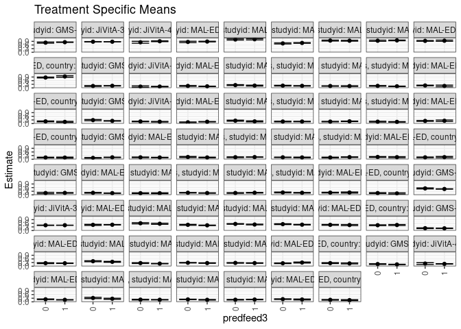

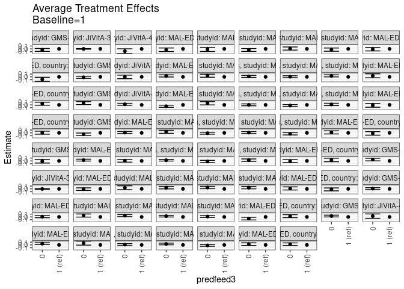

[figure not shown]

## Results Table

### Parameter: TSM

| agecat | studyid | country | intervention_level | baseline_level | estimate | ci_lower | ci_upper |
| --- | --- | --- | --- | --- | --- | --- | --- |
| 0-3 months | GMS-Nepal | NEPAL | 1 | NA | 0.8311437 | 0.8118244 | 0.8504630 |
| 0-3 months | GMS-Nepal | NEPAL | 0 | NA | 0.7945524 | 0.7468540 | 0.8422509 |
| 0-3 months | JiVitA-3 | BANGLADESH | 1 | NA | 0.8701340 | 0.8662378 | 0.8740303 |
| 0-3 months | JiVitA-3 | BANGLADESH | 0 | NA | 0.8695064 | 0.8581487 | 0.8808640 |
| 0-3 months | JiVitA-4 | BANGLADESH | 1 | NA | 0.9086134 | 0.8758597 | 0.9413670 |
| 0-3 months | JiVitA-4 | BANGLADESH | 0 | NA | 0.8253396 | 0.7468047 | 0.9038746 |
| 0-3 months | MAL-ED | BANGLADESH | 1 | NA | 0.8840196 | 0.8581322 | 0.9099071 |
| 0-3 months | MAL-ED | BANGLADESH | 0 | NA | 0.8525623 | 0.7956962 | 0.9094285 |
| 0-3 months | MAL-ED | BRAZIL | 1 | NA | 1.0745798 | 1.0180807 | 1.1310790 |
| 0-3 months | MAL-ED | BRAZIL | 0 | NA | 1.0550294 | 1.0080962 | 1.1019626 |
| 0-3 months | MAL-ED | INDIA | 1 | NA | 0.7690455 | 0.7414062 | 0.7966848 |
| 0-3 months | MAL-ED | INDIA | 0 | NA | 0.7292398 | 0.6863220 | 0.7721576 |
| 0-3 months | MAL-ED | NEPAL | 1 | NA | 0.9524516 | 0.9136713 | 0.9912319 |
| 0-3 months | MAL-ED | NEPAL | 0 | NA | 0.9642883 | 0.9255422 | 1.0030344 |
| 0-3 months | MAL-ED | PERU | 1 | NA | 0.9791041 | 0.9505516 | 1.0076566 |
| 0-3 months | MAL-ED | PERU | 0 | NA | 0.9520022 | 0.9033654 | 1.0006391 |
| 0-3 months | MAL-ED | SOUTH AFRICA | 1 | NA | 0.9523500 | 0.9011160 | 1.0035840 |
| 0-3 months | MAL-ED | SOUTH AFRICA | 0 | NA | 0.9405047 | 0.9083267 | 0.9726826 |
| 0-3 months | MAL-ED | TANZANIA, UNITED REPUBLIC OF | 1 | NA | 0.9447034 | 0.8831285 | 1.0062783 |
| 0-3 months | MAL-ED | TANZANIA, UNITED REPUBLIC OF | 0 | NA | 0.8571731 | 0.8195852 | 0.8947610 |
| 3-6 months | GMS-Nepal | NEPAL | 1 | NA | 0.4870994 | 0.4718529 | 0.5023458 |
| 3-6 months | GMS-Nepal | NEPAL | 0 | NA | 0.5335994 | 0.4908352 | 0.5763637 |
| 3-6 months | JiVitA-3 | BANGLADESH | 1 | NA | 0.4393441 | 0.4352899 | 0.4433983 |
| 3-6 months | JiVitA-3 | BANGLADESH | 0 | NA | 0.4377056 | 0.4256646 | 0.4497466 |
| 3-6 months | MAL-ED | BANGLADESH | 1 | NA | 0.4774349 | 0.4588557 | 0.4960141 |
| 3-6 months | MAL-ED | BANGLADESH | 0 | NA | 0.4692117 | 0.4269442 | 0.5114793 |
| 3-6 months | MAL-ED | BRAZIL | 1 | NA | 0.5602164 | 0.5135808 | 0.6068521 |
| 3-6 months | MAL-ED | BRAZIL | 0 | NA | 0.6013094 | 0.5517604 | 0.6508585 |
| 3-6 months | MAL-ED | INDIA | 1 | NA | 0.4306587 | 0.4093370 | 0.4519804 |
| 3-6 months | MAL-ED | INDIA | 0 | NA | 0.4724653 | 0.4371343 | 0.5077963 |

[output cut: 110 more lines]

### Parameter: E(Y)

| agecat | studyid | country | intervention_level | baseline_level | estimate | ci_lower | ci_upper |
| --- | --- | --- | --- | --- | --- | --- | --- |
| 0-3 months | GMS-Nepal | NEPAL | NA | NA | 0.8249513 | 0.8069417 | 0.8429610 |
| 0-3 months | JiVitA-3 | BANGLADESH | NA | NA | 0.8700727 | 0.8663508 | 0.8737946 |
| 0-3 months | JiVitA-4 | BANGLADESH | NA | NA | 0.9009158 | 0.8704585 | 0.9313731 |
| 0-3 months | MAL-ED | BANGLADESH | NA | NA | 0.8782283 | 0.8546037 | 0.9018529 |
| 0-3 months | MAL-ED | BRAZIL | NA | NA | 1.0646542 | 1.0280029 | 1.1013055 |
| 0-3 months | MAL-ED | INDIA | NA | NA | 0.7574589 | 0.7340940 | 0.7808237 |
| 0-3 months | MAL-ED | NEPAL | NA | NA | 0.9584228 | 0.9310012 | 0.9858444 |
| 0-3 months | MAL-ED | PERU | NA | NA | 0.9695845 | 0.9443399 | 0.9948290 |
| 0-3 months | MAL-ED | SOUTH AFRICA | NA | NA | 0.9436816 | 0.9164103 | 0.9709528 |
| 0-3 months | MAL-ED | TANZANIA, UNITED REPUBLIC OF | NA | NA | 0.8823647 | 0.8498032 | 0.9149263 |
| 3-6 months | GMS-Nepal | NEPAL | NA | NA | 0.4947387 | 0.4800952 | 0.5093821 |
| 3-6 months | JiVitA-3 | BANGLADESH | NA | NA | 0.4392001 | 0.4352946 | 0.4431056 |
| 3-6 months | MAL-ED | BANGLADESH | NA | NA | 0.4759067 | 0.4588572 | 0.4929562 |
| 3-6 months | MAL-ED | BRAZIL | NA | NA | 0.5807629 | 0.5466123 | 0.6149135 |
| 3-6 months | MAL-ED | INDIA | NA | NA | 0.4428354 | 0.4243688 | 0.4613020 |
| 3-6 months | MAL-ED | NEPAL | NA | NA | 0.5212569 | 0.5007636 | 0.5417503 |
| 3-6 months | MAL-ED | PERU | NA | NA | 0.4987110 | 0.4795495 | 0.5178726 |
| 3-6 months | MAL-ED | SOUTH AFRICA | NA | NA | 0.4651960 | 0.4389728 | 0.4914192 |
| 3-6 months | MAL-ED | TANZANIA, UNITED REPUBLIC OF | NA | NA | 0.4449049 | 0.4193050 | 0.4705047 |
| 6-9 months | GMS-Nepal | NEPAL | NA | NA | 0.1833726 | 0.1693467 | 0.1973984 |
| 6-9 months | MAL-ED | BANGLADESH | NA | NA | 0.2435771 | 0.2286416 | 0.2585125 |
| 6-9 months | MAL-ED | BRAZIL | NA | NA | 0.3852363 | 0.3576221 | 0.4128505 |
| 6-9 months | MAL-ED | INDIA | NA | NA | 0.2257708 | 0.2103479 | 0.2411937 |
| 6-9 months | MAL-ED | NEPAL | NA | NA | 0.2707612 | 0.2558425 | 0.2856799 |
| 6-9 months | MAL-ED | PERU | NA | NA | 0.2615943 | 0.2459743 | 0.2772143 |
| 6-9 months | MAL-ED | SOUTH AFRICA | NA | NA | 0.2582981 | 0.2366643 | 0.2799319 |
| 6-9 months | MAL-ED | TANZANIA, UNITED REPUBLIC OF | NA | NA | 0.2452641 | 0.2182544 | 0.2722738 |
| 9-12 months | GMS-Nepal | NEPAL | NA | NA | 0.1493494 | 0.1349712 | 0.1637275 |
| 9-12 months | JiVitA-4 | BANGLADESH | NA | NA | 0.1927867 | 0.1760286 | 0.2095447 |
| 9-12 months | MAL-ED | BANGLADESH | NA | NA | 0.1742501 | 0.1603345 | 0.1881656 |
| 9-12 months | MAL-ED | BRAZIL | NA | NA | 0.2870152 | 0.2525341 | 0.3214963 |
| 9-12 months | MAL-ED | INDIA | NA | NA | 0.1750483 | 0.1600136 | 0.1900829 |
| 9-12 months | MAL-ED | NEPAL | NA | NA | 0.1845885 | 0.1697713 | 0.1994057 |
| 9-12 months | MAL-ED | PERU | NA | NA | 0.1859375 | 0.1706537 | 0.2012212 |
| 9-12 months | MAL-ED | SOUTH AFRICA | NA | NA | 0.2134162 | 0.1908275 | 0.2360049 |
| 9-12 months | MAL-ED | TANZANIA, UNITED REPUBLIC OF | NA | NA | 0.1579518 | 0.1360310 | 0.1798726 |
| 12-15 months | GMS-Nepal | NEPAL | NA | NA | 0.1715034 | 0.1574465 | 0.1855603 |
| 12-15 months | JiVitA-4 | BANGLADESH | NA | NA | 0.1088810 | 0.0873587 | 0.1304034 |
| 12-15 months | MAL-ED | BANGLADESH | NA | NA | 0.1349541 | 0.1188584 | 0.1510499 |
| 12-15 months | MAL-ED | BRAZIL | NA | NA | 0.2098691 | 0.1830086 | 0.2367295 |
| 12-15 months | MAL-ED | INDIA | NA | NA | 0.1746076 | 0.1576725 | 0.1915427 |
| 12-15 months | MAL-ED | NEPAL | NA | NA | 0.1530291 | 0.1359519 | 0.1701063 |
| 12-15 months | MAL-ED | PERU | NA | NA | 0.1429995 | 0.1263204 | 0.1596787 |
| 12-15 months | MAL-ED | SOUTH AFRICA | NA | NA | 0.1888436 | 0.1630039 | 0.2146833 |
| 12-15 months | MAL-ED | TANZANIA, UNITED REPUBLIC OF | NA | NA | 0.1670430 | 0.1409337 | 0.1931523 |
| 15-18 months | GMS-Nepal | NEPAL | NA | NA | 0.2313498 | 0.2143055 | 0.2483941 |
| 15-18 months | JiVitA-4 | BANGLADESH | NA | NA | 0.1538108 | 0.1308637 | 0.1767579 |
| 15-18 months | MAL-ED | BANGLADESH | NA | NA | 0.1419687 | 0.1260987 | 0.1578386 |
| 15-18 months | MAL-ED | BRAZIL | NA | NA | 0.2081023 | 0.1789625 | 0.2372420 |
| 15-18 months | MAL-ED | INDIA | NA | NA | 0.1670737 | 0.1513151 | 0.1828322 |
| 15-18 months | MAL-ED | NEPAL | NA | NA | 0.1721904 | 0.1559804 | 0.1884004 |
| 15-18 months | MAL-ED | PERU | NA | NA | 0.1444767 | 0.1256292 | 0.1633242 |
| 15-18 months | MAL-ED | SOUTH AFRICA | NA | NA | 0.2221335 | 0.1931701 | 0.2510970 |
| 15-18 months | MAL-ED | TANZANIA, UNITED REPUBLIC OF | NA | NA | 0.1366378 | 0.1119409 | 0.1613347 |
| 18-21 months | GMS-Nepal | NEPAL | NA | NA | 0.1478606 | 0.1308537 | 0.1648675 |
| 18-21 months | MAL-ED | BANGLADESH | NA | NA | 0.1441563 | 0.1270864 | 0.1612262 |
| 18-21 months | MAL-ED | BRAZIL | NA | NA | 0.1618510 | 0.1358468 | 0.1878551 |
| 18-21 months | MAL-ED | INDIA | NA | NA | 0.1719770 | 0.1564970 | 0.1874571 |
| 18-21 months | MAL-ED | NEPAL | NA | NA | 0.1511761 | 0.1334727 | 0.1688794 |
| 18-21 months | MAL-ED | PERU | NA | NA | 0.1620790 | 0.1430444 | 0.1811137 |
| 18-21 months | MAL-ED | SOUTH AFRICA | NA | NA | 0.1798838 | 0.1527878 | 0.2069798 |
| 18-21 months | MAL-ED | TANZANIA, UNITED REPUBLIC OF | NA | NA | 0.1578080 | 0.1309046 | 0.1847113 |
| 21-24 months | GMS-Nepal | NEPAL | NA | NA | 0.1608641 | 0.1363372 | 0.1853911 |
| 21-24 months | MAL-ED | BANGLADESH | NA | NA | 0.1485991 | 0.1337648 | 0.1634334 |
| 21-24 months | MAL-ED | BRAZIL | NA | NA | 0.1369019 | 0.1132291 | 0.1605747 |
| 21-24 months | MAL-ED | INDIA | NA | NA | 0.1590319 | 0.1452622 | 0.1728016 |
| 21-24 months | MAL-ED | NEPAL | NA | NA | 0.1662354 | 0.1463078 | 0.1861631 |
| 21-24 months | MAL-ED | PERU | NA | NA | 0.1814454 | 0.1615858 | 0.2013051 |
| 21-24 months | MAL-ED | SOUTH AFRICA | NA | NA | 0.1880230 | 0.1639514 | 0.2120945 |
| 21-24 months | MAL-ED | TANZANIA, UNITED REPUBLIC OF | NA | NA | 0.1380758 | 0.1082723 | 0.1678793 |

### Parameter: ATE

| agecat | studyid | country | intervention_level | baseline_level | estimate | ci_lower | ci_upper |
| --- | --- | --- | --- | --- | --- | --- | --- |
| 0-3 months | GMS-Nepal | NEPAL | 1 | 1 | 0.0000000 | 0.0000000 | 0.0000000 |
| 0-3 months | GMS-Nepal | NEPAL | 0 | 1 | -0.0365913 | -0.0880536 | 0.0148711 |
| 0-3 months | JiVitA-3 | BANGLADESH | 1 | 1 | 0.0000000 | 0.0000000 | 0.0000000 |
| 0-3 months | JiVitA-3 | BANGLADESH | 0 | 1 | -0.0006277 | -0.0125102 | 0.0112549 |
| 0-3 months | JiVitA-4 | BANGLADESH | 1 | 1 | 0.0000000 | 0.0000000 | 0.0000000 |
| 0-3 months | JiVitA-4 | BANGLADESH | 0 | 1 | -0.0832738 | -0.1690659 | 0.0025184 |
| 0-3 months | MAL-ED | BANGLADESH | 1 | 1 | 0.0000000 | 0.0000000 | 0.0000000 |
| 0-3 months | MAL-ED | BANGLADESH | 0 | 1 | -0.0314573 | -0.0939386 | 0.0310241 |
| 0-3 months | MAL-ED | BRAZIL | 1 | 1 | 0.0000000 | 0.0000000 | 0.0000000 |
| 0-3 months | MAL-ED | BRAZIL | 0 | 1 | -0.0195504 | -0.0930003 | 0.0538994 |
| 0-3 months | MAL-ED | INDIA | 1 | 1 | 0.0000000 | 0.0000000 | 0.0000000 |
| 0-3 months | MAL-ED | INDIA | 0 | 1 | -0.0398057 | -0.0908534 | 0.0112420 |
| 0-3 months | MAL-ED | NEPAL | 1 | 1 | 0.0000000 | 0.0000000 | 0.0000000 |
| 0-3 months | MAL-ED | NEPAL | 0 | 1 | 0.0118367 | -0.0429827 | 0.0666562 |
| 0-3 months | MAL-ED | PERU | 1 | 1 | 0.0000000 | 0.0000000 | 0.0000000 |
| 0-3 months | MAL-ED | PERU | 0 | 1 | -0.0271018 | -0.0835003 | 0.0292966 |
| 0-3 months | MAL-ED | SOUTH AFRICA | 1 | 1 | 0.0000000 | 0.0000000 | 0.0000000 |
| 0-3 months | MAL-ED | SOUTH AFRICA | 0 | 1 | -0.0118453 | -0.0723461 | 0.0486555 |
| 0-3 months | MAL-ED | TANZANIA, UNITED REPUBLIC OF | 1 | 1 | 0.0000000 | 0.0000000 | 0.0000000 |
| 0-3 months | MAL-ED | TANZANIA, UNITED REPUBLIC OF | 0 | 1 | -0.0875303 | -0.1596712 | -0.0153893 |
| 3-6 months | GMS-Nepal | NEPAL | 1 | 1 | 0.0000000 | 0.0000000 | 0.0000000 |
| 3-6 months | GMS-Nepal | NEPAL | 0 | 1 | 0.0465001 | 0.0010993 | 0.0919009 |
| 3-6 months | JiVitA-3 | BANGLADESH | 1 | 1 | 0.0000000 | 0.0000000 | 0.0000000 |
| 3-6 months | JiVitA-3 | BANGLADESH | 0 | 1 | -0.0016385 | -0.0141147 | 0.0108377 |
| 3-6 months | MAL-ED | BANGLADESH | 1 | 1 | 0.0000000 | 0.0000000 | 0.0000000 |
| 3-6 months | MAL-ED | BANGLADESH | 0 | 1 | -0.0082232 | -0.0543939 | 0.0379475 |
| 3-6 months | MAL-ED | BRAZIL | 1 | 1 | 0.0000000 | 0.0000000 | 0.0000000 |
| 3-6 months | MAL-ED | BRAZIL | 0 | 1 | 0.0410930 | -0.0269510 | 0.1091370 |
| 3-6 months | MAL-ED | INDIA | 1 | 1 | 0.0000000 | 0.0000000 | 0.0000000 |
| 3-6 months | MAL-ED | INDIA | 0 | 1 | 0.0418066 | 0.0005405 | 0.0830727 |

[output cut: 110 more lines]

### Parameter: PAR

| agecat | studyid | country | intervention_level | baseline_level | estimate | ci_lower | ci_upper |
| --- | --- | --- | --- | --- | --- | --- | --- |
| 0-3 months | GMS-Nepal | NEPAL | 1 | NA | -0.0061924 | -0.0149923 | 0.0026076 |
| 0-3 months | JiVitA-3 | BANGLADESH | 1 | NA | -0.0000613 | -0.0012226 | 0.0011000 |
| 0-3 months | JiVitA-4 | BANGLADESH | 1 | NA | -0.0076976 | -0.0157727 | 0.0003775 |
| 0-3 months | MAL-ED | BANGLADESH | 1 | NA | -0.0057913 | -0.0173980 | 0.0058154 |
| 0-3 months | MAL-ED | BRAZIL | 1 | NA | -0.0099256 | -0.0472409 | 0.0273897 |
| 0-3 months | MAL-ED | INDIA | 1 | NA | -0.0115866 | -0.0266436 | 0.0034704 |
| 0-3 months | MAL-ED | NEPAL | 1 | NA | 0.0059712 | -0.0216942 | 0.0336366 |
| 0-3 months | MAL-ED | PERU | 1 | NA | -0.0095196 | -0.0293882 | 0.0103489 |
| 0-3 months | MAL-ED | SOUTH AFRICA | 1 | NA | -0.0086684 | -0.0529475 | 0.0356107 |
| 0-3 months | MAL-ED | TANZANIA, UNITED REPUBLIC OF | 1 | NA | -0.0623386 | -0.1140040 | -0.0106732 |
| 3-6 months | GMS-Nepal | NEPAL | 1 | NA | 0.0076393 | 0.0000003 | 0.0152783 |
| 3-6 months | JiVitA-3 | BANGLADESH | 1 | NA | -0.0001440 | -0.0012400 | 0.0009520 |
| 3-6 months | MAL-ED | BANGLADESH | 1 | NA | -0.0015282 | -0.0101188 | 0.0070624 |
| 3-6 months | MAL-ED | BRAZIL | 1 | NA | 0.0205465 | -0.0136041 | 0.0546971 |
| 3-6 months | MAL-ED | INDIA | 1 | NA | 0.0121767 | -0.0001206 | 0.0244740 |
| 3-6 months | MAL-ED | NEPAL | 1 | NA | 0.0243704 | 0.0036781 | 0.0450627 |
| 3-6 months | MAL-ED | PERU | 1 | NA | 0.0148921 | 0.0007079 | 0.0290763 |
| 3-6 months | MAL-ED | SOUTH AFRICA | 1 | NA | 0.0122067 | -0.0277802 | 0.0521936 |
| 3-6 months | MAL-ED | TANZANIA, UNITED REPUBLIC OF | 1 | NA | -0.0117527 | -0.0476156 | 0.0241102 |
| 6-9 months | GMS-Nepal | NEPAL | 1 | NA | 0.0016130 | -0.0040477 | 0.0072737 |
| 6-9 months | MAL-ED | BANGLADESH | 1 | NA | 0.0015658 | -0.0053942 | 0.0085259 |
| 6-9 months | MAL-ED | BRAZIL | 1 | NA | 0.0239894 | -0.0031822 | 0.0511609 |
| 6-9 months | MAL-ED | INDIA | 1 | NA | 0.0135687 | 0.0021206 | 0.0250169 |
| 6-9 months | MAL-ED | NEPAL | 1 | NA | 0.0135071 | -0.0015432 | 0.0285574 |
| 6-9 months | MAL-ED | PERU | 1 | NA | 0.0045744 | -0.0065236 | 0.0156725 |
| 6-9 months | MAL-ED | SOUTH AFRICA | 1 | NA | -0.0428618 | -0.0768419 | -0.0088816 |
| 6-9 months | MAL-ED | TANZANIA, UNITED REPUBLIC OF | 1 | NA | 0.0185602 | -0.0177498 | 0.0548703 |
| 9-12 months | GMS-Nepal | NEPAL | 1 | NA | 0.0048998 | -0.0002778 | 0.0100774 |
| 9-12 months | JiVitA-4 | BANGLADESH | 1 | NA | 0.0028631 | -0.0048082 | 0.0105344 |
| 9-12 months | MAL-ED | BANGLADESH | 1 | NA | 0.0078457 | 0.0015055 | 0.0141860 |
| 9-12 months | MAL-ED | BRAZIL | 1 | NA | 0.0304045 | -0.0036271 | 0.0644360 |
| 9-12 months | MAL-ED | INDIA | 1 | NA | 0.0030297 | -0.0075966 | 0.0136559 |
| 9-12 months | MAL-ED | NEPAL | 1 | NA | 0.0171027 | 0.0020322 | 0.0321731 |
| 9-12 months | MAL-ED | PERU | 1 | NA | -0.0059682 | -0.0160648 | 0.0041284 |
| 9-12 months | MAL-ED | SOUTH AFRICA | 1 | NA | 0.0196308 | -0.0135264 | 0.0527880 |
| 9-12 months | MAL-ED | TANZANIA, UNITED REPUBLIC OF | 1 | NA | 0.0181918 | -0.0136173 | 0.0500010 |
| 12-15 months | GMS-Nepal | NEPAL | 1 | NA | -0.0023786 | -0.0081790 | 0.0034219 |
| 12-15 months | JiVitA-4 | BANGLADESH | 1 | NA | -0.0001990 | -0.0059588 | 0.0055608 |
| 12-15 months | MAL-ED | BANGLADESH | 1 | NA | 0.0062141 | -0.0009555 | 0.0133837 |
| 12-15 months | MAL-ED | BRAZIL | 1 | NA | 0.0197247 | -0.0059718 | 0.0454211 |
| 12-15 months | MAL-ED | INDIA | 1 | NA | 0.0052057 | -0.0060235 | 0.0164349 |
| 12-15 months | MAL-ED | NEPAL | 1 | NA | 0.0027310 | -0.0145632 | 0.0200253 |
| 12-15 months | MAL-ED | PERU | 1 | NA | 0.0118616 | -0.0002691 | 0.0239922 |
| 12-15 months | MAL-ED | SOUTH AFRICA | 1 | NA | 0.0278604 | -0.0225730 | 0.0782939 |
| 12-15 months | MAL-ED | TANZANIA, UNITED REPUBLIC OF | 1 | NA | 0.0285116 | -0.0093838 | 0.0664071 |
| 15-18 months | GMS-Nepal | NEPAL | 1 | NA | 0.0102144 | 0.0014442 | 0.0189847 |
| 15-18 months | JiVitA-4 | BANGLADESH | 1 | NA | 0.0024394 | -0.0019371 | 0.0068158 |
| 15-18 months | MAL-ED | BANGLADESH | 1 | NA | -0.0088649 | -0.0161855 | -0.0015443 |
| 15-18 months | MAL-ED | BRAZIL | 1 | NA | 0.0272813 | -0.0006088 | 0.0551715 |
| 15-18 months | MAL-ED | INDIA | 1 | NA | 0.0004348 | -0.0100236 | 0.0108932 |
| 15-18 months | MAL-ED | NEPAL | 1 | NA | -0.0117869 | -0.0282196 | 0.0046459 |
| 15-18 months | MAL-ED | PERU | 1 | NA | 0.0053255 | -0.0080031 | 0.0186541 |
| 15-18 months | MAL-ED | SOUTH AFRICA | 1 | NA | -0.0107703 | -0.0599714 | 0.0384309 |
| 15-18 months | MAL-ED | TANZANIA, UNITED REPUBLIC OF | 1 | NA | 0.0048994 | -0.0323479 | 0.0421467 |
| 18-21 months | GMS-Nepal | NEPAL | 1 | NA | -0.0071058 | -0.0137499 | -0.0004617 |
| 18-21 months | MAL-ED | BANGLADESH | 1 | NA | 0.0022765 | -0.0042682 | 0.0088211 |
| 18-21 months | MAL-ED | BRAZIL | 1 | NA | 0.0174627 | -0.0076161 | 0.0425415 |
| 18-21 months | MAL-ED | INDIA | 1 | NA | -0.0036072 | -0.0145303 | 0.0073159 |
| 18-21 months | MAL-ED | NEPAL | 1 | NA | 0.0051243 | -0.0129066 | 0.0231553 |
| 18-21 months | MAL-ED | PERU | 1 | NA | -0.0108715 | -0.0241145 | 0.0023715 |
| 18-21 months | MAL-ED | SOUTH AFRICA | 1 | NA | 0.0130789 | -0.0273253 | 0.0534831 |
| 18-21 months | MAL-ED | TANZANIA, UNITED REPUBLIC OF | 1 | NA | -0.0122989 | -0.0558406 | 0.0312427 |
| 21-24 months | GMS-Nepal | NEPAL | 1 | NA | -0.0016952 | -0.0113303 | 0.0079399 |
| 21-24 months | MAL-ED | BANGLADESH | 1 | NA | 0.0049528 | -0.0012636 | 0.0111692 |
| 21-24 months | MAL-ED | BRAZIL | 1 | NA | 0.0013239 | -0.0215110 | 0.0241588 |
| 21-24 months | MAL-ED | INDIA | 1 | NA | 0.0071598 | -0.0019800 | 0.0162995 |
| 21-24 months | MAL-ED | NEPAL | 1 | NA | -0.0100744 | -0.0300762 | 0.0099274 |
| 21-24 months | MAL-ED | PERU | 1 | NA | 0.0086327 | -0.0055678 | 0.0228332 |
| 21-24 months | MAL-ED | SOUTH AFRICA | 1 | NA | -0.0059196 | -0.0443726 | 0.0325334 |
| 21-24 months | MAL-ED | TANZANIA, UNITED REPUBLIC OF | 1 | NA | 0.0223724 | -0.0208929 | 0.0656377 |